# Deploy and monitor a machine learning workflow for Image Classification

## Setting up this notebook

Notes about the instance size and kernel setup: this notebook has been tested on

1. The `Python 3 (Data Science)` kernel
2. The `ml.t3.medium` instance

## Data Staging

We'll use a sample dataset called CIFAR to simulate the challenges Scones Unlimited are facing in Image Classification. In order to start working with CIFAR we'll need to:

1. Extract the data from a hosting service
2. Transform it into a usable shape and format
3. Load it into a production system

In other words, we're going to do some simple ETL!

### 1. Extract the data from the hosting service

In the cell below, define a function `extract_cifar_data` that extracts python version of the CIFAR-100 dataset. The CIFAR dataaset is open source and generously hosted by the University of Toronto at: https://www.cs.toronto.edu/~kriz/cifar-100-python.tar.gz

```python
import requests

def extract_cifar_data(url, filename="cifar.tar.gz"):
    """A function for extracting the CIFAR-100 dataset and storing it as a gzipped file

    Arguments:
    url      -- the URL where the dataset is hosted
    filename -- the full path where the dataset will be written

    """

    # Todo: request the data from the data url
    # Hint: use `requests.get` method
    r = requests.get(url)
    with open(filename, "wb") as file_context:
        file_context.write(r.content)
    return
```

Let's test it out! Run the following cell and check whether a new file `cifar.tar.gz` is created in the file explorer.

```python
extract_cifar_data("https://www.cs.toronto.edu/~kriz/cifar-100-python.tar.gz")
```

### 2. Transform the data into a usable shape and format

Clearly, distributing the data as a gzipped archive makes sense for the hosting service! It saves on bandwidth, storage, and it's a widely-used archive format. In fact, it's so widely used that the Python community ships a utility for working with them, `tarfile`, as part of its Standard Library. Execute the following cell to decompress your extracted dataset:

```python
import tarfile

with tarfile.open("cifar.tar.gz", "r:gz") as tar:
    tar.extractall()
```

A new folder `cifar-100-python` should be created, containing `meta`, `test`, and `train` files. These files are `pickles` and the [CIFAR homepage](https://www.cs.toronto.edu/~kriz/cifar.html) provides a simple script that can be used to load them. We've adapted the script below for you to run:

```python
import pickle

with open("./cifar-100-python/meta", "rb") as f:
    dataset_meta = pickle.load(f, encoding='bytes')

with open("./cifar-100-python/test", "rb") as f:
    dataset_test = pickle.load(f, encoding='bytes')

with open("./cifar-100-python/train", "rb") as f:
    dataset_train = pickle.load(f, encoding='bytes')
```

```python
# Feel free to explore the datasets

dataset_train.keys()
```

```
dict_keys([b'filenames', b'batch_label', b'fine_labels', b'coarse_labels', b'data'])
```

```python
# Explore data:
dataset_train[b'data']
```

```
array([[255, 255, 255, ...,  10,  59,  79],
       [255, 253, 253, ..., 253, 253, 255],
       [250, 248, 247, ..., 194, 207, 228],
       ...,
       [248, 240, 236, ..., 180, 174, 205],
       [156, 151, 151, ..., 114, 107, 126],
       [ 31,  30,  31, ...,  72,  69,  67]], dtype=uint8)
```

```python
32*32*3
```

```
3072
```

For a simple gut-check, let's transform one of our images. Each 1024 items in a row is a channel (red, green, then blue). Each 32 items in the channel are a row in the 32x32 image. Using python, we can stack these channels into a 32x32x3 array, and save it as a PNG file:

```python
import numpy as np

# Each 1024 in a row is a channel (red, green, then blue)
row = dataset_train[b'data'][0]
red, green, blue = row[0:1024], row[1024:2048], row[2048:]

# Each 32 items in the channel are a row in the 32x32 image
red = red.reshape(32,32)
green = green.reshape(32,32)
blue = blue.reshape(32,32)

# Combine the channels into a 32x32x3 image!
combined = np.dstack((red,green,blue))
```

For a more concise version, consider the following:

```python
# All in one:
test_image = np.dstack((
    row[0:1024].reshape(32,32),
    row[1024:2048].reshape(32,32),
    row[2048:].reshape(32,32)
))
```

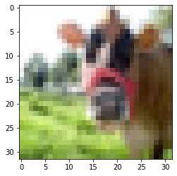

```python
import matplotlib.pyplot as plt
plt.imshow(test_image);
```

Looks like a cow! Let's check the label. `dataset_meta` contains label names in order, and `dataset_train` has a list of labels for each row.

```python
dataset_train[b'fine_labels'][0]
```

```
19
```

Our image has a label of `19`, so let's see what the 19th item is in the list of label names.

```python
print(dataset_meta[b'fine_label_names'][19])
```

```
b'cattle'
```

Ok! 'cattle' sounds about right. By the way, using the previous two lines we can do:

```python
n = 0
print(dataset_meta[b'fine_label_names'][dataset_train[b'fine_labels'][n]])
```

```
b'cattle'
```

Now we know how to check labels, is there a way that we can also check file names? `dataset_train` also contains a `b'filenames'` key. Let's see what we have here:

```python
print(dataset_train[b'filenames'][0])
```

```
b'bos_taurus_s_000507.png'
```

"Taurus" is the name of a subspecies of cattle, so this looks like a pretty reasonable filename. To save an image we can also do:

```python
plt.imsave("Taurus.png", test_image)
```

Your new PNG file should now appear in the file explorer -- go ahead and pop it open to see!

Now that you know how to reshape the images, save them as files, and capture their filenames and labels, let's just capture all the bicycles and motorcycles and save them. Scones Unlimited can use a model that tells these apart to route delivery drivers automatically.

In the following cell, identify the label numbers for Bicycles and Motorcycles:

```python
import pandas as pd

# Todo: Filter the dataset_train and dataset_meta objects to find the label numbers for Bicycle and Motorcycles
for i, name in enumerate(dataset_meta[b'fine_label_names']):
    if name == b'bicycle':
        print(f"Bicycle Row: {i}")
    elif name == b'motorcycle':
        print(f"Motorcycle Row: {i}")
```

```
Bicycle Row: 8
Motorcycle Row: 48
```

Good job! We only need objects with label 8 and 48 -- this drastically simplifies our handling of the data! Below we construct a dataframe for you, and you can safely drop the rows that don't contain observations about bicycles and motorcycles. Fill in the missing lines below to drop all other rows:

```python
#Construct the dataframe
df_train = pd.DataFrame({
    "filenames": dataset_train[b'filenames'],
    "labels": dataset_train[b'fine_labels'],
    "row": range(len(dataset_train[b'filenames']))
})

# Drop all rows from df_train where label is not 8 or 48
df_train = df_train.loc[df_train["labels"].isin([8,48])]

# Decode df_train.filenames so they are regular strings
df_train["filenames"] = df_train["filenames"].apply(
    lambda x: x.decode("utf-8")
)


df_test = pd.DataFrame({
    "filenames": dataset_test[b'filenames'],
    "labels": dataset_test[b'fine_labels'],
    "row": range(len(dataset_test[b'filenames']))
})

# Drop all rows from df_test where label is not 8 or 48
df_test = df_test.loc[df_test["labels"].isin([8,48])]

# Decode df_test.filenames so they are regular strings
df_test["filenames"] = df_test["filenames"].apply(
    lambda x: x.decode("utf-8")
)
```

Now that the data is filtered for just our classes, we can save all our images.

```python
!mkdir ./train
!mkdir ./test
```

In the previous sections we introduced you to several key snippets of code:

1. Grabbing the image data:

```
dataset_train[b'data'][0]
```

1. A simple idiom for stacking the image data into the right shape

```
import numpy as np
np.dstack((
    row[0:1024].reshape(32,32),
    row[1024:2048].reshape(32,32),
    row[2048:].reshape(32,32)
))
```

1. A simple `matplotlib` utility for saving images

```
plt.imsave(path+row['filenames'], target)
```

Compose these together into a function that saves all the images into the `./test` and `./train` directories. Use the comments in the body of the `save_images` function below to guide your construction of the function:

```python
# Using logging setup described in Towards Data Science Blog:
# https://towardsdatascience.com/ultimate-guide-to-python-debugging-854dea731e1b

# Import logging / decorating capabilities
from functools import wraps, partial
import logging

# Define logging configuration
logging.basicConfig(
    filename='project_01.log',
    level=logging.WARNING,
    format= '[%(asctime)s] {%(pathname)s:%(lineno)d} %(levelname)s - %(message)s',
    datefmt='%H:%M:%S'
)

# Test logging categories:
logging.error('Testing logging.error')
logging.warning('Testing logging.warning.')

# Helper function that attaches function as attribute of an object
def attach_wrapper(obj, func=None):
    if func is None:
        return partial(attach_wrapper, obj)
    setattr(obj, func.__name__, func)
    return func

# Actual decorator for logging a function
def log(level, message):
    def decorate(func):
        logger = logging.getLogger(func.__module__)  # Setup logger
        formatter = logging.Formatter(
            '%(asctime)s - %(name)s - %(levelname)s - %(message)s')
        handler = logging.StreamHandler()
        handler.setFormatter(formatter)
        logger.addHandler(handler)
        log_message = f"{func.__name__} - {message}"

        @wraps(func)
        def wrapper(*args, **kwargs):  # Logs the message and before executing the decorated function
            logger.log(level, log_message)
            return func(*args, **kwargs)

        @attach_wrapper(wrapper)  # Attaches "set_level" to "wrapper" as attribute
        def set_level(new_level):  # Function that allows us to set log level
            nonlocal level
            level = new_level

        @attach_wrapper(wrapper)  # Attaches "set_message" to "wrapper" as attribute
        def set_message(new_message):  # Function that allows us to set message
            nonlocal log_message
            log_message = f"{func.__name__} - {new_message}"

        return wrapper
    return decorate
```

```python
#@log(logging.WARN, "save-images")
def save_images(dataset, path, filename, row):
    try:
        #Grab the image data in row-major form
        img = dataset[b'data'][row]
    except:
        logging.error("Failed to grab image data from dataset.")
        return False

    try:
        # Consolidated stacking/reshaping from earlier
        target = np.dstack((
            img[0:1024].reshape(32,32),
            img[1024:2048].reshape(32,32),
            img[2048:].reshape(32,32)
        ))
    except:
        logging.error("Failed to stack and reshape image")
        return False

    try:
        # Save the image
        plt.imsave(path+filename, target)
    except:
        logging.error("Failed to save image")
        return False

    # Return any signal data you want for debugging
    return True




# ## TODO: save ALL images using the save_images function
# for i,j in zip(df_train['row'].tolist(),df_train['filenames'].tolist()):
#     if save_images(dataset_train, "./train/", j, i):
#         pass
#     else:
#         logging.error("Func save_images() did not return True")
#         break

# for i,j in zip(df_test['row'].tolist(),df_test['filenames'].tolist()):
#     if save_images(dataset_test, "./test/", j, i):
#         pass
#     else:
#         logging.error("Func save_images() did not return True")
#         break
```

```python
# Test function:
import unittest

!mkdir ./tmp

class TestNotebook(unittest.TestCase):
    def test_save_images(self):
        self.assertEqual(save_images(dataset_train, "./tmp/", "test.png", 0), True)
        self.assertEqual(save_images([], "./tmp/", "test.png", 0), False)


unittest.main(argv=[''], verbosity=2, exit=False)
```

```
mkdir: cannot create directory ‘./tmp’: File exists
```

```
test_save_images (__main__.TestNotebook) ... ok

----------------------------------------------------------------------
Ran 1 test in 0.004s

OK
```

```
<unittest.main.TestProgram at 0x7f7d4cb7cb38>
```

```python
## TODO: save ALL images using the save_images function
for i,j in zip(df_train['row'].tolist(),df_train['filenames'].tolist()):
    if not save_images(dataset_train, "./train/", j, i):
        logging.error("Func save_images() did not return True")
        break

for i,j in zip(df_test['row'].tolist(),df_test['filenames'].tolist()):
    if not save_images(dataset_test, "./test/", j, i):
        logging.error("Func save_images() did not return True")
        break
```

### 3. Load the data

Now we can load the data into S3.

Using the sagemaker SDK grab the current region, execution role, and bucket.

```python
import sagemaker

session = sagemaker.session.Session()

bucket= session.default_bucket()
print("Default Bucket: {}".format(bucket))

region = session.boto_region_name
print("AWS Region: {}".format(region))

role = sagemaker.get_execution_role()
print("RoleArn: {}".format(role))
```

```
Default Bucket: sagemaker-us-east-1-574453876354
AWS Region: us-east-1
RoleArn: arn:aws:iam::574453876354:role/sagemaker_s3_access
```

With this data we can easily sync your data up into S3!

```python
import os

os.environ["DEFAULT_S3_BUCKET"] = bucket
!aws s3 sync ./train s3://${DEFAULT_S3_BUCKET}/train/
!aws s3 sync ./test s3://${DEFAULT_S3_BUCKET}/test/
```

[output not shown]

[output cut: 1145 more lines]

[output not shown]

And that's it! You can check the bucket and verify that the items were uploaded.

## Model Training

For Image Classification, Sagemaker [also expects metadata](https://docs.aws.amazon.com/sagemaker/latest/dg/image-classification.html) e.g. in the form of TSV files with labels and filepaths. We can generate these using our Pandas DataFrames from earlier:

```python
def to_metadata_file(df, prefix):
    df["s3_path"] = df["filenames"]
    df["labels"] = df["labels"].apply(lambda x: 0 if x==8 else 1)
    return df[["row", "labels", "s3_path"]].to_csv(
        f"{prefix}.lst", sep="\t", index=False, header=False
    )

to_metadata_file(df_train.copy(), "train")
to_metadata_file(df_test.copy(), "test")
```

We can also upload our manifest files:

```python
import boto3

# Upload files
boto3.Session().resource('s3').Bucket(
    bucket).Object('train.lst').upload_file('./train.lst')
boto3.Session().resource('s3').Bucket(
    bucket).Object('test.lst').upload_file('./test.lst')
```

Using the `bucket` and `region` info we can get the latest prebuilt container to run our training job, and define an output location on our s3 bucket for the model. Use the `image_uris` function from the SageMaker SDK to retrieve the latest `image-classification` image below:

```python
# Use the image_uris function to retrieve the latest 'image-classification' image
region_name = boto3.Session().region_name
algo_image = sagemaker.image_uris.retrieve(region=region_name, framework="image-classification")
s3_output_location = f"s3://{bucket}/models/image_model"
```

We're ready to create an estimator! Create an estimator `img_classifier_model` that uses one instance of `ml.p2.xlarge`. Ensure that y ou use the output location we defined above - we'll be referring to that later!

```python
img_classifier_model = sagemaker.estimator.Estimator(
    algo_image,
    role=role,
    instance_count=1,
    instance_type='ml.p2.xlarge',
    volume_size=30,
    max_run=1*60*60, # terminate if it takes longer than 1 hour
    input_mode="File",
    output_path=s3_output_location,
    sagemaker_session=session,
)
```

We can also set a few key hyperparameters and define the inputs for our model:

```python
img_classifier_model.set_hyperparameters(
    image_shape='3,32,32', # TODO: Fill in
    num_classes=2, # TODO: Fill in
    num_training_samples=len(df_train) # TODO: fill in
)
```

The `image-classification` image uses four input channels with very specific input parameters. For convenience, we've provided them below:

```python
from sagemaker.debugger import Rule, rule_configs
from sagemaker.session import TrainingInput
model_inputs = {
        "train": sagemaker.inputs.TrainingInput(
            s3_data=f"s3://{bucket}/train/",
            content_type="application/x-image"
        ),
        "validation": sagemaker.inputs.TrainingInput(
            s3_data=f"s3://{bucket}/test/",
            content_type="application/x-image"
        ),
        "train_lst": sagemaker.inputs.TrainingInput(
            s3_data=f"s3://{bucket}/train.lst",
            content_type="application/x-image"
        ),
        "validation_lst": sagemaker.inputs.TrainingInput(
            s3_data=f"s3://{bucket}/test.lst",
            content_type="application/x-image"
        )
}
```

Great, now we can train the model using the model_inputs. In the cell below, call the `fit` method on our model,:

```python
## TODO: train your model
img_classifier_model.fit(model_inputs)
```

```
2021-11-26 16:33:53 Starting - Starting the training job...
2021-11-26 16:34:09 Starting - Launching requested ML instancesProfilerReport-1637944433: InProgress
.........
2021-11-26 16:35:43 Starting - Preparing the instances for training.........
2021-11-26 16:37:24 Downloading - Downloading input data
2021-11-26 16:37:24 Training - Downloading the training image........Docker entrypoint called with argument(s): train

2021-11-26 16:38:44 Training - Training image download completed. Training in progress.[11/26/2021 16:38:42 INFO 140441389135680] Reading default configuration from /opt/amazon/lib/python3.7/site-packages/image_classification/default-input.json: {'use_pretrained_model': 0, 'num_layers': 152, 'epochs…
[11/26/2021 16:38:42 INFO 140441389135680] Merging with provided configuration from /opt/ml/input/config/hyperparameters.json: {'num_classes': '2', 'num_training_samples': '1000', 'image_shape': '3,32,32'}
[11/26/2021 16:38:42 INFO 140441389135680] Final configuration: {'use_pretrained_model': 0, 'num_layers': 152, 'epochs': 30, 'learning_rate': 0.1, 'lr_scheduler_factor': 0.1, 'optimizer': 'sgd', 'momentum': 0, 'weight_decay': 0.0001, 'beta_1': 0.9, 'beta_2': 0.999, 'eps': 1e-08, 'gamma': 0.9, 'mini_…
[11/26/2021 16:38:42 INFO 140441389135680] Searching for .lst files in /opt/ml/input/data/train_lst.
[11/26/2021 16:38:42 INFO 140441389135680] Creating record files for train.lst
[11/26/2021 16:38:43 INFO 140441389135680] Done creating record files...
[11/26/2021 16:38:43 INFO 140441389135680] Searching for .lst files in /opt/ml/input/data/validation_lst.
[11/26/2021 16:38:43 INFO 140441389135680] Creating record files for test.lst
[11/26/2021 16:38:43 INFO 140441389135680] Done creating record files...
[11/26/2021 16:38:43 INFO 140441389135680] use_pretrained_model: 0
[11/26/2021 16:38:43 INFO 140441389135680] multi_label: 0
[11/26/2021 16:38:43 INFO 140441389135680] Performing random weight initialization
[11/26/2021 16:38:43 INFO 140441389135680] ---- Parameters ----
[11/26/2021 16:38:43 INFO 140441389135680] num_layers: 152
[11/26/2021 16:38:43 INFO 140441389135680] data type: <class 'numpy.float32'>
[11/26/2021 16:38:43 INFO 140441389135680] epochs: 30
[11/26/2021 16:38:43 INFO 140441389135680] optimizer: sgd
[11/26/2021 16:38:43 INFO 140441389135680] momentum: 0.9
[11/26/2021 16:38:43 INFO 140441389135680] weight_decay: 0.0001
[11/26/2021 16:38:43 INFO 140441389135680] learning_rate: 0.1
[11/26/2021 16:38:43 INFO 140441389135680] num_training_samples: 1000
[11/26/2021 16:38:43 INFO 140441389135680] mini_batch_size: 32
[11/26/2021 16:38:43 INFO 140441389135680] image_shape: 3,32,32
[11/26/2021 16:38:43 INFO 140441389135680] num_classes: 2
[11/26/2021 16:38:43 INFO 140441389135680] augmentation_type: None
[11/26/2021 16:38:43 INFO 140441389135680] kv_store: device
[11/26/2021 16:38:43 INFO 140441389135680] checkpoint_frequency not set, will store the best model
[11/26/2021 16:38:43 INFO 140441389135680] --------------------
[11/26/2021 16:38:43 INFO 140441389135680] Setting number of threads: 3
[16:38:52] /opt/brazil-pkg-cache/packages/AIAlgorithmsMXNet/AIAlgorithmsMXNet-1.3.x_ecl_Cuda_10.1.x.6753.0/AL2_x86_64/generic-flavor/src/src/operator/nn/./cudnn/./cudnn_algoreg-inl.h:97: Running performance tests to find the best convolution algorithm, this can take a while... (setting env variable …
[11/26/2021 16:39:10 INFO 140441389135680] Epoch[0] Batch [20]#011Speed: 34.738 samples/sec#011accuracy=0.559524
[11/26/2021 16:39:16 INFO 140441389135680] Epoch[0] Train-accuracy=0.620968
[11/26/2021 16:39:16 INFO 140441389135680] Epoch[0] Time cost=23.808
```

[output cut: 117 more lines]

```
[11/26/2021 16:47:42 INFO 140441389135680] Epoch[27] Time cost=16.663
[11/26/2021 16:47:43 INFO 140441389135680] Epoch[27] Validation-accuracy=0.763393
[11/26/2021 16:47:55 INFO 140441389135680] Epoch[28] Batch [20]#011Speed: 57.263 samples/sec#011accuracy=0.968750
[11/26/2021 16:48:01 INFO 140441389135680] Epoch[28] Train-accuracy=0.966734
[11/26/2021 16:48:01 INFO 140441389135680] Epoch[28] Time cost=16.657
[11/26/2021 16:48:02 INFO 140441389135680] Epoch[28] Validation-accuracy=0.828125
[11/26/2021 16:48:14 INFO 140441389135680] Epoch[29] Batch [20]#011Speed: 56.976 samples/sec#011accuracy=0.991071
[11/26/2021 16:48:19 INFO 140441389135680] Epoch[29] Train-accuracy=0.986895
[11/26/2021 16:48:19 INFO 140441389135680] Epoch[29] Time cost=16.728
[11/26/2021 16:48:21 INFO 140441389135680] Epoch[29] Validation-accuracy=0.828125

2021-11-26 16:48:48 Uploading - Uploading generated training model
2021-11-26 16:49:28 Completed - Training job completed
Training seconds: 740
Billable seconds: 740
```

If all goes well, you'll end up with a model topping out above `.8` validation accuracy. With only 1000 training samples in the CIFAR dataset, that's pretty good. We could definitely pursue data augmentation & gathering more samples to help us improve further, but for now let's proceed to deploy our model.